# Titanic survival prediction

BSHT Michielsen MSc

This notebook aims at predicting the survivability of people who were on the titanic during its disasterous sinking by applying decision trees. The main advantage of decision trees is that humans can easily understand and reproduce the sequence of decisions taken by the model to predict the target, which makes it one of the most transparent machine learning algorithms available.

[figure not shown]

```python
import sklearn
import pandas as pd
import seaborn

print("scikit-learn version:", sklearn.__version__)     # 1.1.3
print("pd version:", pd.__version__)            # 1.5.1
print("seaborn version:", seaborn.__version__)          # 0.12.1
```

```
scikit-learn version: 1.1.3
pd version: 1.5.1
seaborn version: 0.12.1
```

# 📦 Data provisioning

After loading the data from the csv file, it is immediately apparent that the dataset contains a large number of missing values. This notebook is an example on training a decision tree, and not on resolving data quality issues. Nevertheless a little bit of fixing is needed to make it work. Thus, the rather destructive approach of simply removing the features `pnumber`, `name`, `home.dest` and `ticket` is taken, as well as simply filling the missing values of `age` by its mean. Surely there are perhaps better ways to handle the missing data in `age` but they are outside the scope of this example.

```python
df = pd.read_csv("Titanic.csv")
df_copy = df.copy()
df.sample(5)
```

|  | pnumber | pclass | survived | name | age | embarked | home.dest | room | ticket | boat | sex |
| --- | --- | --- | --- | --- | --- | --- | --- | --- | --- | --- | --- |
| 448 | 449 | 2nd | 0 | Hold, Mr Stephen | 42.0 | Southampton | England / Sacramento, CA | NaN | NaN | NaN | male |
| 454 | 455 | 2nd | 0 | Hunt, Mr George Henry | 33.0 | Southampton | Philadelphia, PA | NaN | NaN | NaN | male |
| 450 | 451 | 2nd | 0 | Hood, Mr Ambrose, Jr | 21.0 | Southampton | New Forest, England | NaN | NaN | NaN | male |
| 830 | 831 | 3rd | 0 | Goodwin, Master Sidney L. | 6.0 | Southampton | Wiltshire, England Niagara Falls, NY | NaN | NaN | NaN | male |
| 829 | 830 | 3rd | 0 | Goodwin, Miss Jessie A. | 10.0 | Southampton | Wiltshire, England Niagara Falls, NY | NaN | NaN | NaN | female |

```python
df = df.drop(["pnumber", "name", "home.dest", "ticket"], axis=1)
df["age"] =  df["age"].fillna(df["age"].mean())
```

## 📃 Sample the data

A random sample of 5 observations from the data after the data provisioning.

```python
df.sample(5)
```

|  | pclass | survived | age | embarked | room | boat | sex |
| --- | --- | --- | --- | --- | --- | --- | --- |
| 518 | 2nd | 1 | 20.000000 | Cherbourg | D-38 | 7 | male |
| 1254 | 3rd | 0 | 31.194181 | NaN | NaN | NaN | male |
| 1075 | 3rd | 0 | 31.194181 | NaN | NaN | NaN | male |
| 181 | 1st | 0 | 44.000000 | Queenstown | NaN | -230 | male |
| 44 | 1st | 0 | 33.000000 | Southampton | NaN | NaN | male |

# Preprocessing

## 🆔 Encoding

The features `pclass` and `sex` are currently categorical, but can fairly easily be mapped to integers because `sex` is binary and therefore can be encoded using `0` and `1`. Whereas `class` is ordinal, first class is better than second class and third class, so the integers `1`, `2` and `3` make sense.

```python
df["pclass"] = df["pclass"].map({"1st":1, "2nd":2, "3rd":3}).astype(int)
df["sex"] = df["sex"].map({"male":0, "female":1}).astype(int)
df.sample(5)
```

|  | pclass | survived | age | embarked | room | boat | sex |
| --- | --- | --- | --- | --- | --- | --- | --- |
| 729 | 3 | 1 | 22.000000 | Queenstown | NaN | NaN | 1 |
| 665 | 3 | 0 | 45.000000 | Cherbourg | NaN | NaN | 1 |
| 1093 | 3 | 0 | 31.194181 | NaN | NaN | NaN | 1 |
| 382 | 2 | 0 | 21.000000 | Southampton | NaN | NaN | 0 |
| 238 | 1 | 1 | 24.000000 | Southampton | NaN | 7 | 0 |

The feature `embarked` is categorical too, but it is a little harder to turn into an integer because the values are not binary and neither ordinal (none of the values is better than another in any sense). Therefore, a different approach is needed. Given that only one value is ever true (a passenger could not have embarked both of two different places) the approach of [one-hot](https://en.wikipedia.org/wiki/One-hot) encoding will suffice here. The pd function named `get_dummies` can be used for this. The result is that the dataset now has three new features with names equal to the values of the `embarked` column and in just one of them there is a `1` which indicates the place in which the passenger embarked. Note that the fact that sometimes `embarked` is missing is ignored, and this approach will simply put `0` in every one of the three new features, which is technically wrong.

```python
df = pd.concat([df, pd.get_dummies(df["embarked"])], axis=1)
df = df.drop("embarked", axis=1)
df.sample(5)
```

|  | pclass | survived | age | room | boat | sex | Cherbourg | Queenstown | Southampton |
| --- | --- | --- | --- | --- | --- | --- | --- | --- | --- |
| 1293 | 3 | 1 | 31.194181 | NaN | NaN | 1 | 0 | 0 | 0 |
| 61 | 1 | 1 | 31.194181 | NaN | 6 | 1 | 0 | 0 | 1 |
| 1000 | 3 | 0 | 31.194181 | NaN | NaN | 1 | 0 | 0 | 0 |
| 675 | 3 | 0 | 18.000000 | NaN | NaN | 0 | 0 | 0 | 1 |
| 443 | 2 | 1 | 53.000000 | NaN | 4 | 1 | 0 | 0 | 1 |

pd.get_dummies(df["embarked"]) creates separate binary columns for each category: C Q S 1 0 0 (Cherbourg) 0 1 0 (Queenstown) 0 0 1 (Southampton)

df = pd.concat([df, pd.get_dummies(df["embarked"])], axis=1)

Adds the new collumns to the dataframe

axis=0 Operates along rows (vertically, across columns)

axis=1 Operates along columns (horizontally, across rows)

The features `room` and `boat` are dropped instead of being encoded, because in the case of `room` it is hard to turn it into a numeric value that is actually useful for the machine to train on. The room number itself is probably useless, however, the distance from the room to a lifeboat might actually have been an interesting feature. However, without a map of the titanic, this distance cannot be inferred from the room number. The case of `boat` is different because `survived` and `boat` are not independent. In order to survive you need to have reached a lifeboat, so any value in the `boat` feature is highly likely to result in having survived the disaster. However, a conclusion like "If you were in a life boat, you are likely to have survived." is rather trivial. Therefore `boat` becomes a feature that is not going to be selected anyway. Note that for legibility reasons the target is moved to the end of the data set.

```python
df = df[["pclass", "sex", "age", "Cherbourg", "Queenstown", "Southampton", "survived"]]
df.sample(5)
```

|  | pclass | sex | age | Cherbourg | Queenstown | Southampton | survived |
| --- | --- | --- | --- | --- | --- | --- | --- |
| 560 | 2 | 1 | 31.194181 | 0 | 0 | 1 | 1 |
| 1295 | 3 | 0 | 31.194181 | 0 | 0 | 0 | 0 |
| 495 | 2 | 0 | 30.000000 | 0 | 0 | 1 | 0 |
| 906 | 3 | 0 | 31.194181 | 0 | 0 | 0 | 1 |
| 175 | 1 | 0 | 54.000000 | 0 | 0 | 1 | 0 |

## 💡 Feature selection

A heatmap will be used to select a suitable set of features to predict the `survived` target upon.

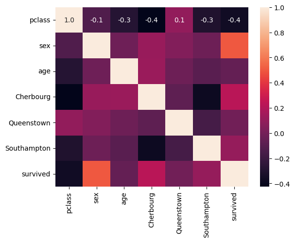

```python
correlations = df.corr()
plot = seaborn.heatmap(correlations, cbar=True, annot=True, fmt=".1f")
```

Correlation measures how two things move together—whether one changes when the other changes.

Positive correlation (+) → When one goes up, the other goes up. ✅ Example: More study hours → Higher grades.

Negative correlation (-) → When one goes up, the other goes down. ❌ Example: More junk food → Lower health score.

No correlation (0) → They don’t affect each other. 🤷 Example: Shoe size & intelligence.

💡 The closer to +1 or -1, the stronger the connection!

Apparently the class of the ticket and the sex of the passenger are most indicative for survivability. Since we choose the value `1` for female and `0` for male, the correlation coefficient of positive `0.5` indicates that when the value for `sex` goes up, survivability also goes up, so females have a higher chance to survive than males. Similarly when the value for `pclass` goes up (and therefore the class goes down, because 1st class is higher than 3rd class) survivability goes down, in other words, 1st class passenger were more likely to survive than other classes. Additionally, passengers that embarked in Cherbourg seem to have a little higher survivability too, which is not easily explained. Surprisingly however, the age does have little influence, which is unexpected because the consensus in case of disaster of that time was that women and children are to be saved first. This is probably why `sex` does correlate well with `survived`, as mentioned before, but does not explain why `age` does not correlate well.

For now, no investigation into age is undertaken but merely the features `pclass`, `sex` and `Cherbourg` are selected to continue.

```python
features = ["pclass", "sex", "Cherbourg"]
target = "survived"

X = df[features]
y = df[target]
```

## 🪓 Splitting into train/test

```python
from sklearn.model_selection import train_test_split
X_train, X_test, y_train, y_test = train_test_split(X, y, test_size=.2)
print("There are in total", len(X), "observations, of which", len(X_train), "are now in the train set, and", len(X_test), "in the test set.")
```

```
There are in total 1313 observations, of which 1050 are now in the train set, and 263 in the test set.
```

# Modelling

```python
from sklearn.tree import DecisionTreeClassifier
model = DecisionTreeClassifier()
model.fit(X_train, y_train)
score = model.score(X_test, y_test)
print("Accuracy:", score)
```

```
Accuracy: 0.7946768060836502
```

It is possible to ask the decision tree which features it considers import in deciding the outcome and which features it considers less import. The values are fractions which add up to 100%.

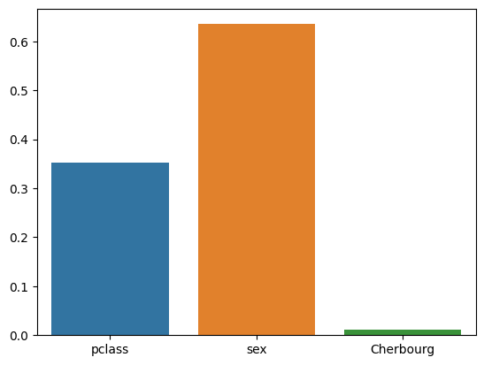

```python
plot = seaborn.barplot(y=model.feature_importances_, x=features)
```

The biggest advantage of using a decision tree is that the tree itself can be drawn as to give insight in what actually happens inside the tree. For humans this is an understandable process that greatly improves the transparency of the modelling step.

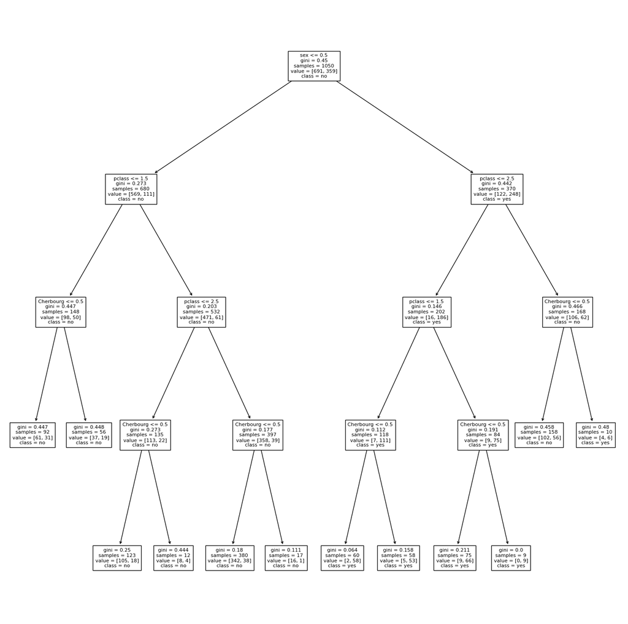

```python
target_names = ["no", "yes"]
import matplotlib.pyplot as plt
plt.figure(figsize=(18,18))
from sklearn.tree import plot_tree
plot_tree(model, fontsize=8, feature_names=features, class_names=target_names)
plt.show()
```

In a Decision Tree, when the model splits a feature, it follows this rule:

✅ Values that are LESS THAN OR EQUAL (<=) go to the LEFT branch. ✅ Values that are GREATER (>) go to the RIGHT branch.

The Gini Impurity measures how "mixed" a node is.

If a node is pure (only contains one class, like all survivors or all non-survivors), gini = 0. If a node is perfectly mixed (50% survived, 50% didn’t), gini = 0.5. The closer to 0, the cleaner the split. ✅ Lower gini means a better, more pure split.

💡 Example:

gini = 0.0 → All passengers in this node either survived or died (Perfect classification ✅). gini = 0.5 → Half survived, half died (Worst case ❌).

## Class in this case means:

If most people didn’t survive → class = no (0). If most people survived → class = yes (1).

## Value in this case means:

# Evaluation

This notebook produces slightly different results every time it is ran due to the random train/test split. However, calculating the evaluation metrics for the train set as well as the test set gives us insight in whether the model is overfitted or not. If the trainset results are a lot better than the testset results, it means that the model is trained a little too well on the train set and therefore generalizes badly in the real world.

```python
from sklearn.metrics import classification_report

print("Train set:")
predictions = model.predict(X_train)
report = classification_report(y_train, predictions, target_names=target_names)
print(report)

print("Test set:")
predictions = model.predict(X_test)
report = classification_report(y_test, predictions, target_names=target_names)
print(report)
```

```
Train set:
              precision    recall  f1-score   support

          no       0.80      0.97      0.88       691
         yes       0.91      0.53      0.67       359

    accuracy                           0.82      1050
   macro avg       0.85      0.75      0.78      1050
weighted avg       0.84      0.82      0.81      1050

Test set:
              precision    recall  f1-score   support

          no       0.78      0.95      0.86       173
         yes       0.85      0.49      0.62        90

    accuracy                           0.79       263
   macro avg       0.81      0.72      0.74       263
weighted avg       0.80      0.79      0.78       263
```

Running the notebook a few times one will notice that sometimes the results for the testset are a little different from the trainset, but not greatly so. In conclusion, the model is not overfitted and will generalize well in the real world.

# Inference

Now let us try a few fictionally persons, and see whether they would have survived the Titanic Disaster or not.

First class female, not from Cherbourg.

```python
data = {"pclass": 1, "sex": 1, "Cherbourg": 0}

X_inference = pd.DataFrame([data])
prediction = model.predict_proba(X_inference)
result = pd.DataFrame()
result["Outcome"] = target_names
result["Probability"] = prediction[0]
result
```

|  | Outcome | Probability |
| --- | --- | --- |
| 0 | no | 0.033333 |
| 1 | yes | 0.966667 |

# Explanation

## Inference 1

This converts the dictionary into a DataFrame so that we can feed it to the model

X_inference = pd.DataFrame([data])

Additionally "model.predict_proba(X_inference)" makes a propability prediction not just a Yes or No

Second class male, from Cherbourg.

```python
data = {"pclass": 2, "sex": 0, "Cherbourg": 1}

X_inference = pd.DataFrame([data])
prediction = model.predict_proba(X_inference)
result = pd.DataFrame()
result["Outcome"] = target_names
result["Probability"] = prediction[0]
result
```

|  | Outcome | Probability |
| --- | --- | --- |
| 0 | no | 0.666667 |
| 1 | yes | 0.333333 |

First class male, from Cherbourg.

```python
data = {"pclass": 1, "sex": 0, "Cherbourg": 1}

X_inference = pd.DataFrame([data])
prediction = model.predict_proba(X_inference)
result = pd.DataFrame()
result["Outcome"] = target_names
result["Probability"] = prediction[0]
result
```

|  | Outcome | Probability |
| --- | --- | --- |
| 0 | no | 0.660714 |
| 1 | yes | 0.339286 |

# Start of preparation for a new model

## Model 2

# Data Provisioning

In this section we are going to follow the same rather destructive approach of simply removing the features `pnumber`, `name`, `home.dest` and `ticket`.

```python
df_new = df_copy
df_new.sample(5)
```

|  | pnumber | pclass | survived | name | age | embarked | home.dest | room | ticket | boat | sex |
| --- | --- | --- | --- | --- | --- | --- | --- | --- | --- | --- | --- |
| 469 | 470 | 2nd | 0 | Kirkland, Rev Charles Leonard | NaN | Queenstown | Glasgow / Bangor, ME | NaN | NaN | NaN | male |
| 298 | 299 | 1st | 1 | Endres, Miss Caroline Louise | NaN | Cherbourg | New York, NY | C-45 | 17754 L224 10s 6d | 4 | female |
| 839 | 840 | 3rd | 0 | Haas, Miss Aloisia | NaN | NaN | NaN | NaN | NaN | NaN | female |
| 676 | 677 | 3rd | 0 | Bostandyeff, Mr Guentcho | 26.0 | Southampton | Bulgaria Chicago, IL | NaN | NaN | NaN | male |
| 441 | 442 | 2nd | 0 | Hickman, Mr Stanley George | 21.0 | Southampton | West Hampstead, London / Neepawa, MB | NaN | NaN | NaN | male |

```python
df_new = df_new.drop(["pnumber", "name", "home.dest", "ticket"], axis=1)
df_new["age"] =  df_new["age"].fillna(df["age"].mean())
```

# Sample the data

```python
df_new.sample(5)
```

|  | pclass | survived | age | embarked | room | boat | sex |
| --- | --- | --- | --- | --- | --- | --- | --- |
| 378 | 2nd | 0 | 30.000000 | Southampton | NaN | NaN | female |
| 764 | 3rd | 0 | 25.000000 | Southampton | NaN | NaN | male |
| 805 | 3rd | 0 | 31.194181 | Southampton | NaN | NaN | male |
| 925 | 3rd | 0 | 31.194181 | NaN | NaN | NaN | male |
| 587 | 2nd | 1 | 31.194181 | Southampton | NaN | NaN | female |

# Preprocessing

## 🆔 Encoding

The features `pclass` and `sex` are currently categorical, but can fairly easily be mapped to integers because `sex` is binary and therefore can be encoded using `0` and `1`. Whereas `class` is ordinal, first class is better than second class and third class, so the integers `1`, `2` and `3` make sense.

```python
df_new["pclass"] = df_new["pclass"].map({"1st":1, "2nd":2, "3rd":3}).astype(int)
df_new["sex"] = df_new["sex"].map({"male":0, "female":1}).astype(int)
df_new.sample(5)
```

|  | pclass | survived | age | embarked | room | boat | sex |
| --- | --- | --- | --- | --- | --- | --- | --- |
| 1258 | 3 | 1 | 31.194181 | NaN | NaN | NaN | 0 |
| 853 | 3 | 0 | 31.194181 | NaN | NaN | NaN | 0 |
| 683 | 3 | 0 | 31.194181 | Queenstown | NaN | NaN | 1 |
| 320 | 1 | 0 | 31.194181 | Cherbourg | NaN | NaN | 1 |
| 849 | 3 | 0 | 31.194181 | NaN | NaN | NaN | 0 |

The embarked feature is categorical but neither binary nor ordinal, meaning it can't be directly converted into a meaningful numeric value. To handle this, one-hot encoding is used, creating separate columns for each embarkation point (Cherbourg, Queenstown, Southampton). Each row contains a 1 in the column corresponding to the embarkation location, while missing values are incorrectly represented as all 0s.

```python
df_new = pd.concat([df_new, pd.get_dummies(df_new["embarked"])], axis=1)
df_new = df_new.drop(["embarked", "Cherbourg"], axis=1)
df_new.sample(5)
```

|  | pclass | survived | age | room | boat | sex | Queenstown | Southampton |
| --- | --- | --- | --- | --- | --- | --- | --- | --- |
| 517 | 2 | 0 | 31.194181 | NaN | -287 | 0 | 0 | 1 |
| 811 | 3 | 0 | 31.194181 | NaN | NaN | 0 | 1 | 0 |
| 265 | 1 | 1 | 31.194181 | NaN | D | 1 | 0 | 0 |
| 77 | 1 | 1 | 31.194181 | NaN | A | 0 | 0 | 1 |
| 251 | 1 | 1 | 62.000000 | NaN | 6 | 1 | 0 | 0 |

The features `room` and `boat` are dropped instead of being encoded, because in the case of `room` it is hard to turn it into a numeric value that is actually useful for the machine to train on. The room number itself is probably useless, however, the distance from the room to a lifeboat might actually have been an interesting feature. However, without a map of the titanic, this distance cannot be inferred from the room number. The case of `boat` is different because `survived` and `boat` are not independent. In order to survive you need to have reached a lifeboat, so any value in the `boat` feature is highly likely to result in having survived the disaster. However, a conclusion like "If you were in a life boat, you are likely to have survived." is rather trivial. Therefore `boat` becomes a feature that is not going to be selected anyway. Note that for legibility reasons the target is moved to the end of the data set.

```python
df_new = df_new[["pclass", "sex", "age", "Queenstown", "Southampton", "survived"]]
df.sample(5)
```

|  | pclass | sex | age | Cherbourg | Queenstown | Southampton | survived |
| --- | --- | --- | --- | --- | --- | --- | --- |
| 215 | 1 | 0 | 55.000000 | 1 | 0 | 0 | 0 |
| 66 | 1 | 0 | 31.194181 | 0 | 0 | 1 | 0 |
| 1278 | 3 | 1 | 31.194181 | 0 | 0 | 0 | 0 |
| 184 | 1 | 0 | 55.000000 | 0 | 0 | 1 | 0 |
| 1018 | 3 | 0 | 31.194181 | 0 | 0 | 0 | 0 |

Apparently the class of the ticket and the sex of the passenger are most indicative for survivability. Since we choose the value `1` for female and `0` for male, the correlation coefficient of positive `0.5` indicates that when the value for `sex` goes up, survivability also goes up, so females have a higher chance to survive than males. Similarly when the value for `pclass` goes up (and therefore the class goes down, because 1st class is higher than 3rd class) survivability goes down, in other words, 1st class passenger were more likely to survive than other classes. Additionally, passengers that embarked in Cherbourg seem to have a little higher survivability too, which is not easily explained. Surprisingly however, the age does have little influence, which is unexpected because the consensus in case of disaster of that time was that women and children are to be saved first. This is probably why `sex` does correlate well with `survived`, as mentioned before, but does not explain why `age` does not correlate well.

```python
features_new = ["pclass", "sex"]
target_new = "survived"

X_new = df_new[features_new]
y_new = df_new[target_new]
```

## 🪓 Splitting into train/test

```python
from sklearn.model_selection import train_test_split
X_new_train, X_new_test, y_new_train, y_new_test = train_test_split(X_new, y_new, test_size=.2)
print("There are in total", len(X_new), "observations, of which", len(X_new_train), "are now in the train set, and", len(X_new_test), "in the test set.")
```

```
There are in total 1313 observations, of which 1050 are now in the train set, and 263 in the test set.
```

# Modelling

```python
from sklearn.tree import DecisionTreeClassifier
model_new = DecisionTreeClassifier()
model_new.fit(X_new_train, y_new_train)
score_new = model_new.score(X_new_test, y_new_test)
print("Accuracy:", score)
```

```
Accuracy: 0.7946768060836502
```

### 🔥 Feature Importance

✅ Why It’s Useful

- Helps identify which features matter most for predictions.
- Allows us to remove redundant features (like Cherbourg), making the model simpler and more efficient.
- Avoids overfitting by ensuring the model only learns from relevant data.

```python
print(model.feature_importances_)
print(model_new.feature_importances_)
```

```
[0.35280955 0.63507315 0.0121173 ]
[0.37243764 0.62756236]
```

### 🔥 Reducing Model Complexity - Task Completed 🚀

# Start of preparation for a new model

## Model 3 Iris

### Iris Classification with a Decision Tree

- In this section, we use a Decision Tree to classify Iris plants. Since trees don't need scaling, we use the raw data.
- We load the Iris dataset and convert the `species` column from text to numerical codes.
- astype("category") converts the species column into a categorical type.
- .cat.codes assigns a unique integer (0, 1, 2) to each species, which is required for the model.

Aditionally we sample the data to help us wiht understanding it.

```python
import pandas as pd
from sklearn.model_selection import train_test_split
from sklearn.tree import DecisionTreeClassifier
import matplotlib.pyplot as plt
from sklearn.tree import plot_tree

columns = ["sepal_length", "sepal_width", "petal_length", "petal_width", "species"]
df = pd.read_csv("http://archive.ics.uci.edu/ml/machine-learning-databases/iris/iris.data", names=columns)
df["species"] = df["species"].astype("category").cat.codes
df.sample(10)
```

|  | sepal_length | sepal_width | petal_length | petal_width | species |
| --- | --- | --- | --- | --- | --- |
| 15 | 5.7 | 4.4 | 1.5 | 0.4 | 0 |
| 14 | 5.8 | 4.0 | 1.2 | 0.2 | 0 |
| 125 | 7.2 | 3.2 | 6.0 | 1.8 | 2 |
| 1 | 4.9 | 3.0 | 1.4 | 0.2 | 0 |
| 32 | 5.2 | 4.1 | 1.5 | 0.1 | 0 |
| 0 | 5.1 | 3.5 | 1.4 | 0.2 | 0 |
| 62 | 6.0 | 2.2 | 4.0 | 1.0 | 1 |
| 64 | 5.6 | 2.9 | 3.6 | 1.3 | 1 |
| 28 | 5.2 | 3.4 | 1.4 | 0.2 | 0 |
| 105 | 7.6 | 3.0 | 6.6 | 2.1 | 2 |

# Split the Data

## Separate features and target, then split into training and testing sets.

```python
X = df.drop("species", axis=1)
y = df["species"]

X_train, X_test, y_train, y_test = train_test_split(X, y, test_size=0.2)
```

# Train the Decision Tree

## Create and train the Decision Tree model, then print its accuracy.

```python
model = DecisionTreeClassifier()
model.fit(X_train, y_train)
print("Accuracy:", model.score(X_test, y_test))
```

```
Accuracy: 0.9
```

# Draw the Tree

## Visualize the Decision Tree to see how it classifies the data.

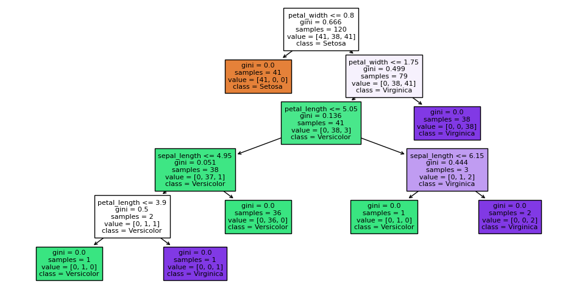

```python
plt.figure(figsize=(12, 6))
plot_tree(
    model,
    feature_names=X.columns,
    class_names=["Setosa", "Versicolor", "Virginica"],
    filled = True,
    fontsize=8
)
plt.show()
```

Additionally, I set filled=True, which sets the color of each node based on the class it represents (or the class distribution within the node). This enhances readability, making it easier to distinguish branches at a glance rather than relying solely on text.

And even though two nodes belong to the same class, they can have different shades of the same color. This happens because the color intensity reflects the purity of the node—how confident the model is about a classification.

- Darker shades indicate a higher confidence in that class.
- Lighter shades mean the node contains a mix of multiple classes and is less certain.

# Printing the importance of each feature!

```python
print(columns)
print("Feature Importances:", model.feature_importances_)
```

```
['sepal_length', 'sepal_width', 'petal_length', 'petal_width', 'species']
Feature Importances: [0.0285266  0.         0.04102907 0.93044433]
```